# Time Series: A First Course with Bootstrap Starter

# Lesson 5-7: MA Representation

- We know the autocovariances of an MA process, but how about an ARMA?
- Given the ARMA polynomials $\theta (z)$ and $\phi (z) = 1 - \sum_{j=1}^p \phi_j z^j$, we need algorithms to compute the autocovariances.

## Paradigm 5.7.1. Method 1 for ARMA Autocovariances

- First determine the coefficients of $\psi (z)$, the MA representation. Then compute
  $$\gamma (h) = \sum_{j \geq 0 } \psi_j \psi_{j+|h|} \sigma^2,$$
  which follows from the AGF.
- We get $\psi_j$ recursively by using $\psi (z) \phi (z) = \theta (z)$, so that the $\theta_j$ coefficients equal the convolution of $\psi_j$ and $\phi_j$.
- Letting $\phi_j = 0$ for $j > p$ and $\theta_j =0$ for $j > q$, we obtain
  $$\psi_j = \theta_j + \sum_{k=1}^j \phi_k \psi_{j-k}.$$
- We can also obtain a direct formula using ODE theory.

## Example 5.7.2. Cyclic ARMA(2,1) Process

- We define an ARMA(2,1) process with cyclic properties.
- For $\rho \in (0,1)$ and $\omega \in (0,\pi)$, let $\{ X_t \}$ satisfy
  $$( 1 - 2 \rho \cos (\omega) B + \rho^2 B^2) X_t = (1 - \rho \cos (\omega)
  B) Z_t.$$
- The roots of $\phi (z) = 1 - 2 \rho \cos(\omega) z + \rho^2 z^2$ are $\rho^{-1} e^{\pm i \omega}$.
- We use ODE theory with initial conditions $\psi_0 = 1$,
  $$\psi_1 = \theta_1 + \psi_0 \phi_1 = \rho \cos (\omega),$$
  and eventually find $\psi_j = \rho^j \cos (\omega j)$ for $j \geq 0$.

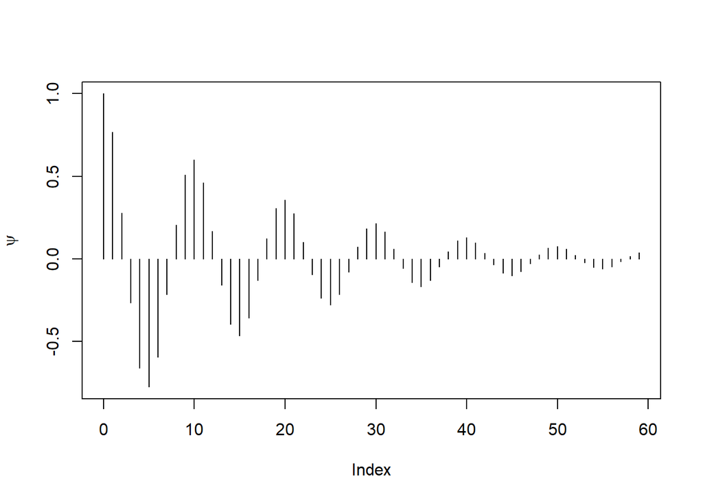

```r
rho <- .95
omega <- pi/5
lag <- 60
psi <- (rho^(seq(1,lag)-1))*cos((seq(1,lag)-1)*omega)
plot(ts(psi,start=0),type="h",xlab="Index",ylab=expression(psi))
```

- From the MA($\infty$) representation, we obtain the autocovariance:
  $$\gamma (k) = \frac{ \sigma^2}{2} \, \rho^k \,
  \left( \frac{ \cos (\omega k) }{1 - \rho^2} +
  \frac{ \cos (\omega k) - \rho^2 \cos ( \omega (k-2)) }{ 1 - 2 \rho^2
  \cos (2 \omega) + \rho^4 } \right).$$
- We rewrite this formula slightly and implement in R.

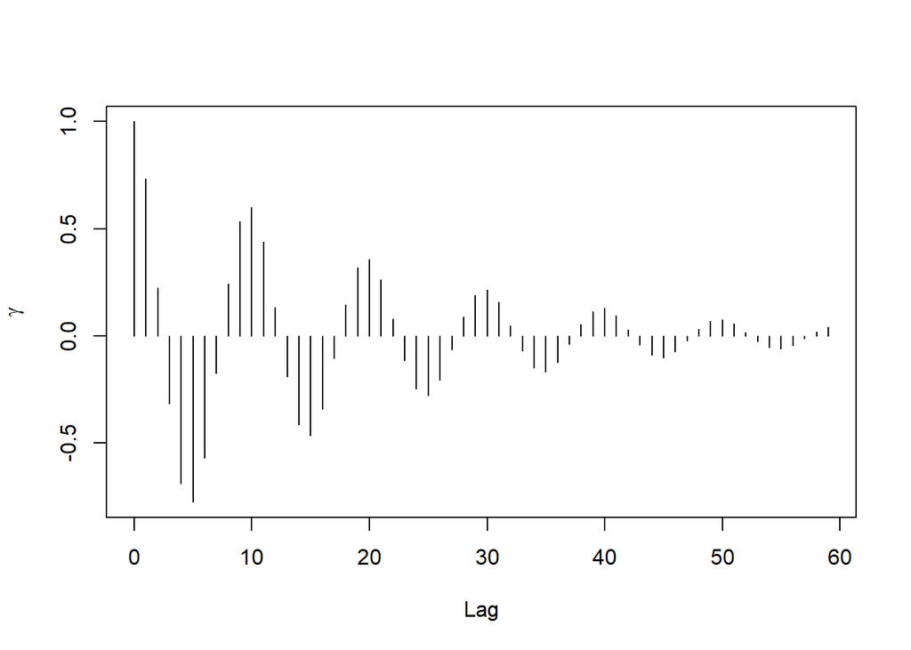

```r
const1 <- 1/(1-rho^2) + (1 - rho^2*cos(2*omega))/(1 - 2*rho^2*cos(2*omega) + rho^4)
const2 <- rho^2*sin(2*omega)/(1 - 2*rho^2*cos(2*omega) + rho^4)
gamma <- .5*(rho^(seq(1,lag)-1))*(cos((seq(1,lag)-1)*omega)*const1 - sin((seq(1,lag)-1)*omega)*const2)
gamma <- gamma/(const1/2)
plot(ts(gamma,start=0),type="h",xlab="Lag",ylab=expression(gamma))
```